# Vignette 1 - Understanding the Results of MCIA

Max Mattessich

Joaquin Reyna

Anna Konstorum

9/1/2022

## Introduction

In the mini-lectures we covered in detail the math behind MCIA as well as a generic pipeline. In this vignette we will cover the most important functions within the nipalsMCIA package as well as downstream analyses that help can interpret the MCIA decomposition. MCIA is applicable to any kind of multi-block data. For this vignette we are using a cancer data set from (Meng et al., 2016) that includes 21 subjects with three data blocks. The data blocks include mRNA levels (12895 features), microRNA levels (537 features) and protein levels (7016 features). Without a multi-block method, researchers may try to use feature reduction methods on each block individually but this strategy ignores relationships between different blocks or under-appreciates signals which are specific to one block. In the context of the NCI60 data set and this vignette, we will show you the power of MCIA to find important relationships between mRNA, microRNA and proteins. More specifically, we will show you how to interpret the global factor scores in Part 1 and global loadings in Part 2.

**Preview of the NCI60 dataset**

The NCI60 data set has been included with the nipalsMCIA package and is easily available as show below:

```r
# load the dataset, uses the name data_blocks
data(NCI60)
data_blocks$mrna[1:5,1:3]
```

```
##            5-HT3C2_1_mrna A1BG-AS1_2_mrna A2LD1_3_mrna
## CNS.SF_268           0.53            0.35        -0.05
## CNS.SF_295          -0.42            0.54        -1.04
## CNS.SF_539           0.00            0.80         0.85
## CNS.SNB_19           0.50           -0.24         0.12
## CNS.SNB_75          -0.27           -0.88        -0.36
```

```r
data_blocks$miRNA[1:5,1:3]
```

```
##            MI0000060_miRNA MI0000061_miRNA MI0000061_miRNA.1
## CNS.SF_268           11.91            6.71             13.11
## CNS.SF_295           11.94            7.13             12.86
## CNS.SF_539           11.50            5.79             12.10
## CNS.SNB_19           13.16            6.23             13.65
## CNS.SNB_75           12.63            6.62             12.97
```

```r
data_blocks$prot[1:5,1:3]
```

```
##            STAU1_1_prot NRAS_2_prot HRAS_3_prot
## CNS.SF_268     5.712331    7.385177    5.758845
## CNS.SF_295     0.000000    6.327175    0.000000
## CNS.SF_539     0.000000    6.597432    0.000000
## CNS.SNB_19     0.000000    6.891811    0.000000
## CNS.SNB_75     0.000000    6.125612    0.000000
```

**Running and Reviewing the MCIA output**  
We can compute the MCIA decomposition with the first 10 global factors by using:

```r
mcia_results <- nipals_multiblock(data_blocks, preprocMethod='colprofile',
                                  num_PCs = 10, tol=1e-12, plots = 'none')
```

The results is a list of various decomposition matrices for MCIA and few other values:

```r
names(mcia_results)
```

```
## [1] "global_scores"       "global_loadings"     "block_score_weights"
## [4] "block_scores"        "block_loadings"      "eigvals"
## [7] "preprocMethod"
```

The `global_scores` matrix is represented by $\mathbf{F}$, that is $n \times r$, where $n$ is the number of samples and $r$ is the number of factors chosen by the user with the `num_PCs = r` argument. Each column of this matrix represents one of the orders of global factors computed, i.e.
$$\mathbf{F} = \begin{pmatrix}
| & |& & |\\
\mathbf{f}^{(1)} &\mathbf{f}^{(2)} & \hdots & \mathbf{f}^{(r)}\\
| & |& & |
\end{pmatrix} \in \mathbb{R}^{n \times r}$$
This matrix encodes a low-dimensional representation of the data set, with the $i$-th row representing a set of $r$-dimensional coordinates for the $i$-th sample.

The `global_loadings` matrix is represented by $\mathbf{A}$ tht is $p \times r$, where $p$ is the number of features across all omics and $r$ is as before. Each column of this matrix represents one of the orders of global loadings computed, i.e.
$$\mathbf{A} = \begin{pmatrix}
| & |& & |\\
\mathbf{a}^{(1)} &\mathbf{a}^{(2)} & \hdots & \mathbf{a}^{(r)}\\
| & |& & |
\end{pmatrix} \in \mathbb{R}^{p \times r}$$
This matrix encodes the contribution of each feature to the low-dimensional representation.

The remainder of this vignette will be broken down into two sections, **Part 1: Interpreting Global Factor Scores** and **Part 2: Interpreting Global Loadings** where we show how to interpret $\mathbf{F}$ and $\mathbf{A}$, respectively.

## Part 1: Interpreting Global Factor Scores

### nipals_multiblock() Generates Basic Visualizations

In the introduction we showed how to calculate the MCIA decomposition using `nipals_multiblock()` but used the parameter `plots='none'` to avoid the default plotting behavior of this function. By default, this function will generate two plots which help establish an initial intuition for the MCIA decomposition. Here we will re-run `nipals_multiblock()` and omit the `plots` parameter (default=all):

```r
mcia_results <- nipals_multiblock(data_blocks, preprocMethod='colprofile',
                                  num_PCs = 10, tol=1e-12)
```

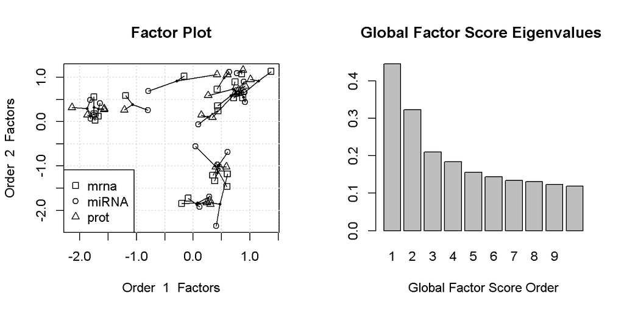

The first plot visualizes each sample using factor 1 and 2 as a lower dimensional representation (Factor plot). Each sample is actually represented by 4 points, a center point (solid block dot) which represents to global factor score, a mRNA factor score (square), a miRNA factor score (circle), and a protein factor score (triangle). The last three omic-specific block factor scores are connected to the global factor point by lines. If a block factor scores is plotted far from its corresponding global factor score then this is an indication that the block does not agree with/contribute to the trend found by the global decomposition but can also be an proxy for batch effects within a particular block if points from a block are consistently far away from their global point. As an example, we can take a look at the global factor score at $(-1.1, 0.4)$, the block factor scores are all quite near which suggests all three omics are contributing somewhat equally, this is contrast to the global factor score at $(-0.3, 0.9)$ where the mRNA factor score is close but the mRNA and miRNA are far from their respective global factor score.

The second plot is a scree plot of singular values corresponding to global factors, higher values assign a greater importance and can be interpreted exactly the same as an eigenvalue scree plot in principal component analysis.

### Visualizing a Factor Plot with Only Global Factor Scores

For clustering, it is useful to look at global factor scores without block factor scores. The `MCIA_plots()` function can be used to generate such a plot using `plotType=projection_global` as show below:

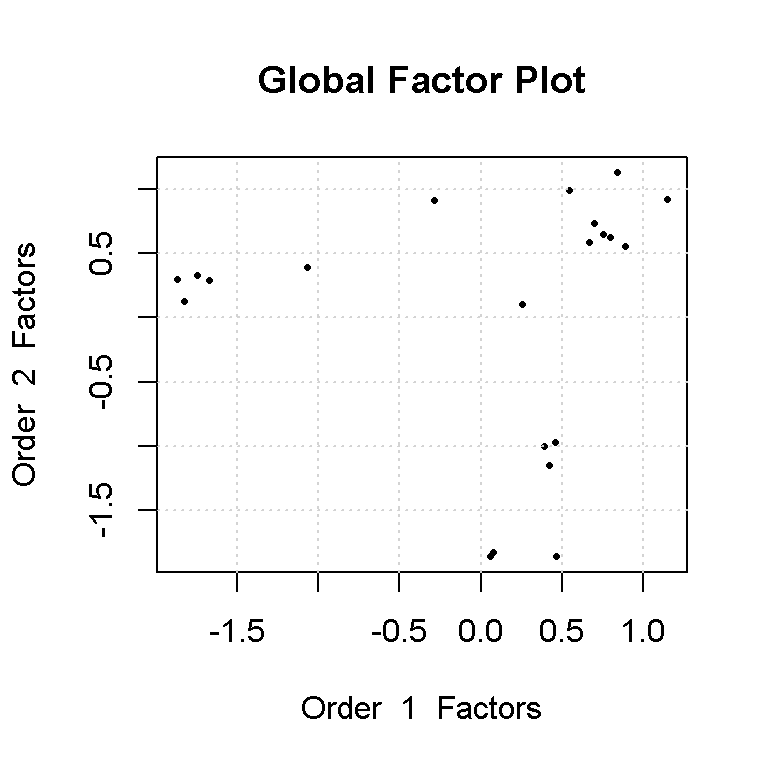

```r
MCIA_plots(mcia_results,'projection_global',orders = c(1,2), legend_loc = "bottomleft")
```

In addition, factor plots are most helpful when points are colored by a meaningful label such as cancer type. The `MCIA_plots()` function can include such data using the `metadata` argument. The `metadata` arguments requires a dataframe where rows are samples and columns are different labels, allowing for a variety of visualization objectives/explorations. For instance, each of the 21 samples in the NCI-60 dataset represents a patient with one of three cancer types: CNS, Leukemia, or Melanoma. Thus we create a metadata dataframe with a column for cancer type, `cancerType`:

```r
CNS = 1:6; LEU = 7:12; ME = 13:21;
nameslist <- list(1:21)
nameslist[CNS] <- "CNS"
nameslist[LEU] <- "Leukemia"
nameslist[ME] <- "Melanoma"
metadata_NCI60 <- data.frame(cancerType = unlist(nameslist))
row.names(metadata_NCI60) <- rownames(data_blocks[[1]])

#View(metadata_NCI60)
```

This dataframe can be passed into the `metadata` argument of `nipals_multiblock()` or added directly to `mcia_results`.

```r
mcia_results <- nipals_multiblock(data_blocks, preprocMethod='colprofile',
                                  metadata = metadata_NCI60,
                                  plots = 'none',num_PCs = 10, tol=1e-12)
# Alternative method for adding metadata:
mcia_results$metadata <- metadata_NCI60
```

The `coloring` argument of `MCIA_plots()` can be used to determine which column of `metadata` is used for coloring the projection plots. In this case the column is `cancerType`:

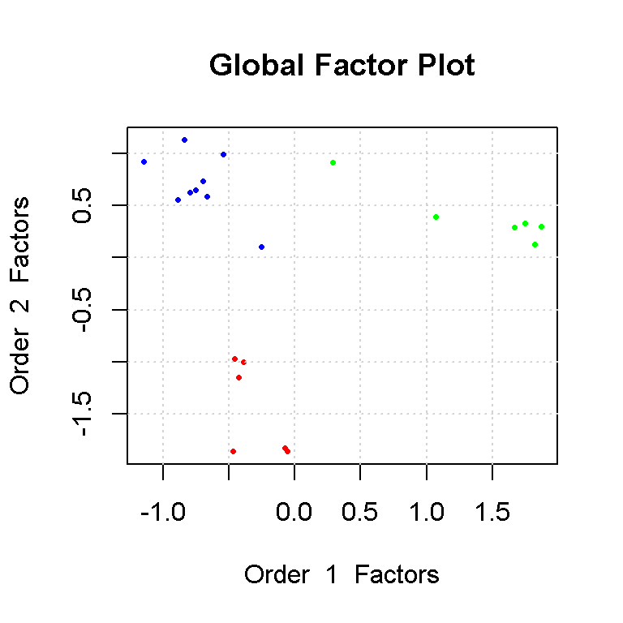

```r
MCIA_plots(mcia_results,'projection_global',orders = c(1,2),coloring = 'cancerType',
           legend_loc = "bottomleft")
```

Clusters of samples can be computed from the global factor scores using any method, such as k-means clustering and visualized similarly.

### Visualizing the clustering of samples by factor scores

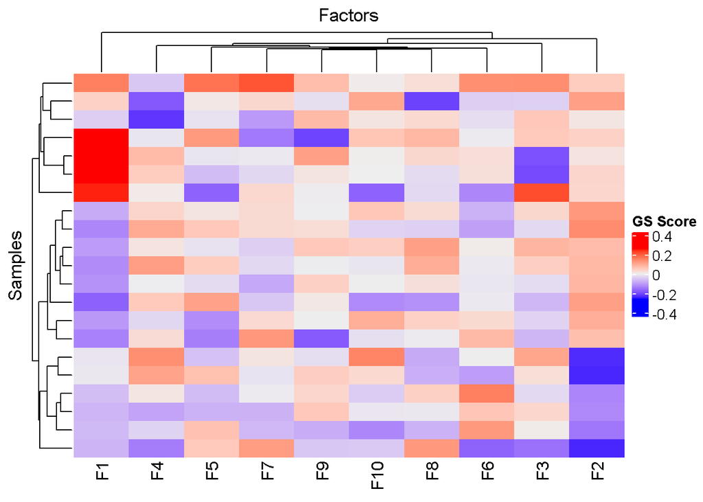

```r
gs_scores = mcia_results$global_scores
global_scores_heatmap_ComplexHeatmap(gs_scores)
```

## Part 2: Interpreting Global Loadings

In addition to the global scores matrix, MCIA also calculates a global loadings matrix $A$ that is $p\times r$.

### Pseudoeigenvalues representing the contribution of each omic to the global factor score

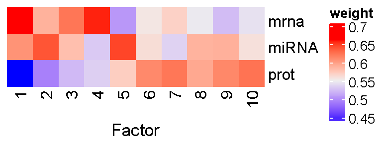

```r
## Should make into a function
bs_weights<-as.matrix(data.frame(mcia_results$block_score_weights))
colnames(bs_weights)<-c(1:10)
Heatmap(bs_weights, cluster_columns=FALSE, cluster_rows=FALSE, name = "weight",
                        column_title_side = "bottom", column_title = "Factor")
```

### Scree Plot: Visualizing the top features per factor

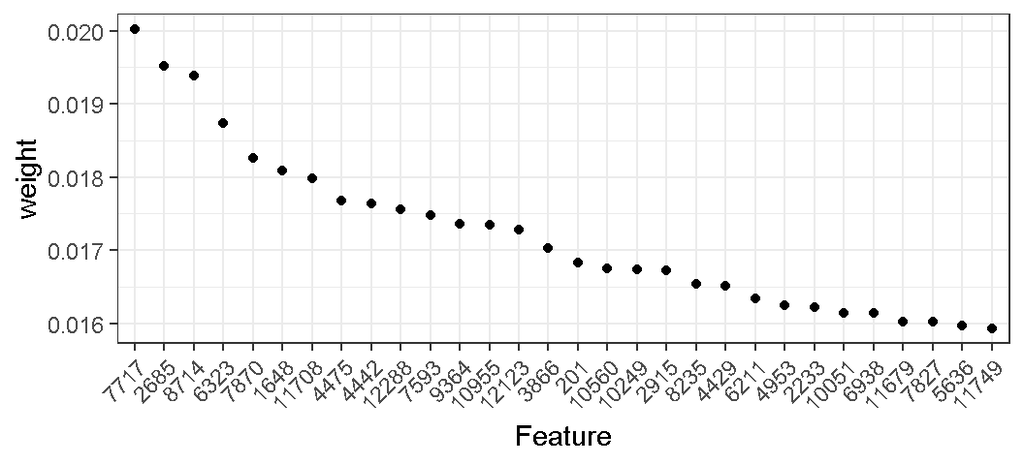

```r
# make into function
gl<-mcia_results$global_loadings
omic_list<-gsub("^.*_", "", rownames(gl))
factor<-4
gl_f<-data.frame(gl[,factor])
gl_f$omic<-omic_list
colnames(gl_f)<-c("weight",'omic')
gl_f_ord<-gl_f[order(gl_f$weight, decreasing=TRUE),]

# look at mRNA (need to filter since issue with miRNA omic name)
gl_f_ord_mRNA<-gl_f_ord[gl_f_ord$omic=="mrna",]
omic_name<-sub("_.*", "",rownames(gl_f_ord_mRNA) )
gl_f_ord_mRNA$omic_name<-sub("_.*", "",rownames(gl_f_ord_mRNA) )
ggplot(gl_f_ord_mRNA[0:30,], aes(x=factor(omic_name,level=omic_name), y=weight))+
      geom_point()+
      theme_bw()+
      xlab('Feature')+
      theme(axis.text.x=element_text(angle=45, hjust=1))
```

### Pathway analysis for the top factors using data from gene-centric omics blocks

#### Gather data and generate the report

```r
# extract mRNA global loadings
mrna_gfscores <- mcia_results$global_loadings
mrna_rows = str_detect(row.names(mrna_gfscores), '_mrna')
mrna_gfscores <- mrna_gfscores[mrna_rows,]

# rename rows to contain HUGO based gene symbols
row.names(mrna_gfscores) <- str_remove(rownames(mrna_gfscores), "_[0-9]*_.*")

# load pathway data
path.database = '../../data/c2.cp.reactome.v6.2.symbols.gmt'
pathways <- fgsea::gmtPathways(path.database)

# generate the GSEA report
geneset_report = gsea_report(mrna_gfscores, path.database,
                      factors = seq(1,3), pval.thr = 0.05,                            nproc=8)
```

```
## [1] "Running GSEA for Factor1"
## [1] "Running GSEA for Factor2"
## [1] "Running GSEA for Factor3"
```

#### Investigating the GSEA Summary Table

```r
geneset_report[[1]]
```

```
##             min_pval total_pathways
## Factor1 2.757656e-09            118
## Factor2 3.045784e-08             99
## Factor3 7.115552e-21             86
```

As just mentioned, Factor3 contains the most enrichment gene set so we can re-run GSEA for this factor in order to get a full list of enrichment scores across all gene sets:

```r
# re-running GSEA
factor3_paths = fgseaMultilevel(pathways, mrna_gfscores[,3],
                                nPermSimple = 10000, minSize=15,                                 nproc = 4, maxSize=500)
factor3_paths
```

```
##                                                                    pathway
##   1:                      REACTOME_3_UTR_MEDIATED_TRANSLATIONAL_REGULATION
##   2: REACTOME_ABORTIVE_ELONGATION_OF_HIV1_TRANSCRIPT_IN_THE_ABSENCE_OF_TAT
##   3:                                    REACTOME_ACTIVATED_TLR4_SIGNALLING
##   4:          REACTOME_ACTIVATION_OF_ATR_IN_RESPONSE_TO_REPLICATION_STRESS
##   5:                       REACTOME_ACTIVATION_OF_CHAPERONE_GENES_BY_XBP1S
##  ---
## 336:                                 REACTOME_TRIF_MEDIATED_TLR3_SIGNALING
## 337:                                    REACTOME_TRIGLYCERIDE_BIOSYNTHESIS
## 338:                                          REACTOME_TRNA_AMINOACYLATION
## 339:                                    REACTOME_UNFOLDED_PROTEIN_RESPONSE
## 340:                         REACTOME_VIF_MEDIATED_DEGRADATION_OF_APOBEC3G
##              pval        padj    log2err         ES        NES size
##   1: 0.0659174774 0.174757650 0.07137732 -0.2946547 -1.3212893   98
##   2: 0.5940531421 0.698886050 0.02304050  0.2871648  0.9048780   18
```

[output cut: 21 more lines]

If we extract the most significant gene set (below) we can see that the REACTOME_CELL_CYCLE gene set comes up which makes sense given that the NCI60 data set is studying cancer. This analysis can be repeated as necessary to make sense of other gene based factor loadings.

```r
# extracting to most significant gene set
sig_path3 = factor3_paths[min(factor3_paths$pval) == factor3_paths$pval,][1,]

as.list(sig_path3)
```

```
## $pathway
## [1] "REACTOME_CELL_CYCLE"
##
## $pval
## [1] 8.179559e-23
##
## $padj
## [1] 2.78105e-20
##
## $log2err
## [1] 1.237897
##
## $ES
## [1] -0.4993812
##
## $NES
## [1] -2.628799
##
## $size
## [1] 301
##
## $leadingEdge
## $leadingEdge[[1]]
##   [1] "E2F1"      "HIST1H2BM" "PPP2R5C"   "CASC5"     "NINL"      "CCNE2"
##   [7] "POLE"      "RAD21"     "HIST1H4L"  "SYNE2"     "HIST1H4A"  "NEDD1"
##  [13] "RBL1"      "TP53"      "SKP2"      "PCNA"      "TINF2"     "STAG1"
##  [19] "MLF1IP"    "PCM1"      "PLK4"      "CDKN2C"    "AURKB"     "PSME1"
##  [25] "ACTR1A"    "DNA2"      "CENPK"     "MCM8"      "TFDP1"     "H2AFZ"
##  [31] "ALMS1"     "SMC3"      "HSP90AA1"  "H2AFX"     "CENPA"     "ANAPC10"
##  [37] "CEP135"    "PSMA3"     "HIST1H4K"  "TUBGCP3"   "MIS12"     "CCND3"
##  [43] "LMNB1"     "PPP2R5D"   "CEP63"     "CDC25B"    "SGOL1"     "CENPO"
##  [49] "PCNT"      "SPC25"     "ZWINT"     "TERF1"     "MNAT1"     "POLD3"
##  [55] "CDK5RAP2"  "CEP70"     "HIST1H2BH" "CEP57"     "RPA1"      "MAD2L1"
##  [61] "PSMF1"     "HIST1H2BI" "DCTN1"     "CEP250"    "DYNC1I2"   "TUBGCP5"
##  [67] "DIDO1"     "STAG2"     "CENPI"     "RRM2"      "LIG1"      "KIF18A"
##  [73] "PPP2R5E"   "SMARCA5"   "PSMB8"     "MAPRE1"    "DYRK1A"    "HIST1H4C"
##  [79] "ATM"       "PAFAH1B1"  "FGFR1OP"   "SMC1A"     "HIST1H2AB" "MCM10"
##  [85] "SGOL2"     "MCM3"      "MCM2"      "PSMB9"     "ANAPC4"    "CDK1"
##  [91] "PMF1"      "POLA2"     "CENPN"     "MCM6"      "POLE2"     "MAX"
##  [97] "NUMA1"     "MCM7"      "PSMB2"     "CDC7"      "NDEL1"     "CLASP1"
## [103] "MCM5"      "PSME2"     "HJURP"     "E2F2"      "KIF20A"    "LIN52"
## [109] "RPS27"     "BTRC"      "RAD9A"     "HIST1H2AJ" "DCTN3"     "POLA1"
## [115] "KNTC1"     "HIST1H4B"  "DYNLL1"    "PSMB10"    "RAD1"      "PSMB7"
## [121] "WEE1"      "CEP192"    "BUB1"      "KIF2C"     "RFC3"      "TYMS"
## [127] "RBL2"      "CHEK1"     "CEP76"     "KIF23"     "CCDC99"    "FBXO5"
## [133] "AKAP9"     "ORC2"      "CENPJ"     "TUBGCP6"   "CENPQ"     "TAOK1"
## [139] "E2F3"      "CEP290"    "RFWD2"     "RAD17"     "CCNB2"     "AHCTF1"
## [145] "GINS1"     "HDAC1"     "CCNA2"     "WRAP53"    "GINS4"     "GINS2"
## [151] "ORC6"      "AZI1"      "CSNK1D"    "ANAPC1"    "DBF4"      "TERT"
## [157] "CDC25A"    "NUP85"     "HAUS2"     "TERF2IP"   "ITGB3BP"   "CEP72"
```

#### Investigating the Selectivity Score

The second element in the report is the selectivity score which is calculated as follows:
$$S = Selectivity\,Score = (N_c + N_f) / 2L$$
where $N_c$ is the total number of clinical annotations associated with at least one factor, $N_f$ the total number of factors associated with at least one clinical annotation, and $L$ the total number of associations between clinical annotations and factors. $S$ has a maximum value of 1 when each factor is associated with one and only one clinical/biological annotation, and a minimum of 0 in the opposite case. An optimal method should thus maximize its number of factors associated with clinical/biological annotations without having a too low selectivity.

```r
geneset_report[[2]]
```

```
## [1] 0.3118812
```

For the mRNA global loadings we can see that there is low selectivity which suggests that there is some overlap between the signals capture by each factor.